# FitBit Data Analysis

Elizabeth Betts

January 15, 2019

## R Markdown

This is Assignment 1 for Reproducible Research in Coursera’s Data Science specialization track. The purpose of the project was to create a R Markdown document to describe some data collected by FitBit.

## Purpose of project

The purpose of this project was to practice

1. loading and preprocessing data
2. imputing missing values
3. interpreting data to answer research questions

## Data for the assigment was downloaded from the course website

Link to required Dataset: https://d396qusza40orc.cloudfront.net/repdata%2Fdata%2Factivity.zip

The variables included are:

1. steps: Number of steps taking in a 5-minute interval (missing values are coded as NA)
2. date: The date on which the measurement was taken in YYYY-MM-DD format
3. interval: Identifier for the 5-minute interval in which measurement was taken

The dataset is stored in a comma-separated-value (CSV) file and there are a total of 17,568 observations in this dataset.

## Loading and preprocessing the data

```r
if(!file.exists("getdata-projectfiles-UCI HAR Dataset.zip")) {
        temp <- tempfile()
        download.file("http://d396qusza40orc.cloudfront.net/repdata%2Fdata%2Factivity.zip",temp)
        unzip(temp)
        unlink(temp)
}

data <- read.csv("activity.csv")
```

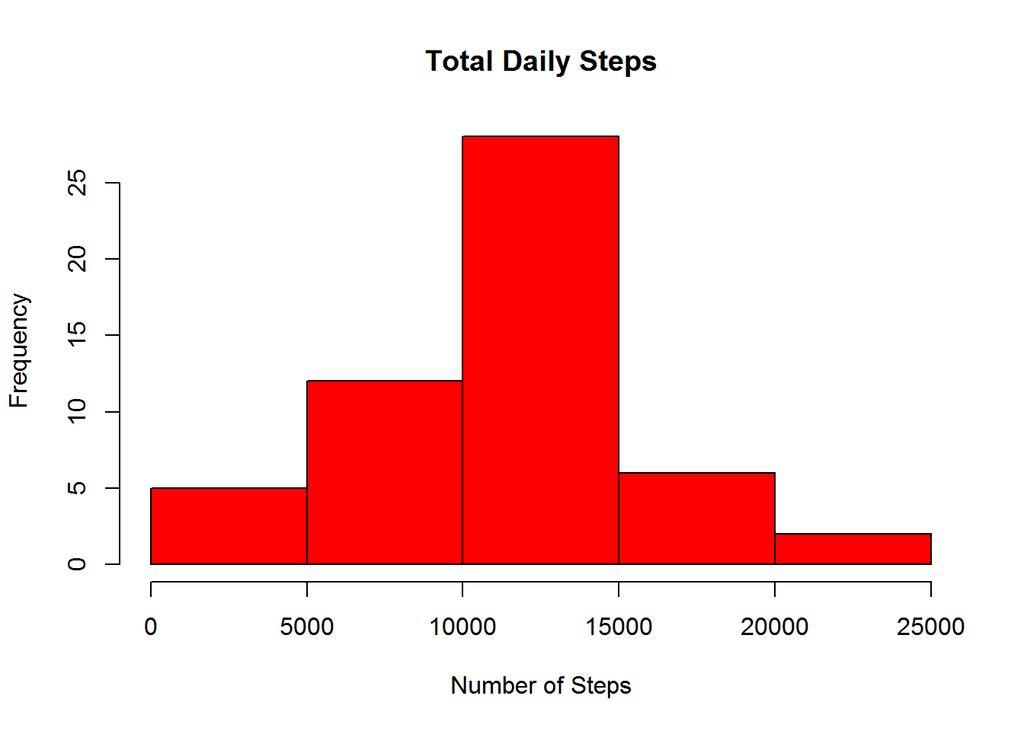

```r
steps_by_day <- aggregate(steps ~ date, data, sum)
hist(steps_by_day$steps, main = paste("Total Daily Steps"), col="red", xlab="Number of Steps")
```

```r
rmean <- mean(steps_by_day$steps)
rmedian <- median(steps_by_day$steps)
```

## What is the average daily activity pattern?

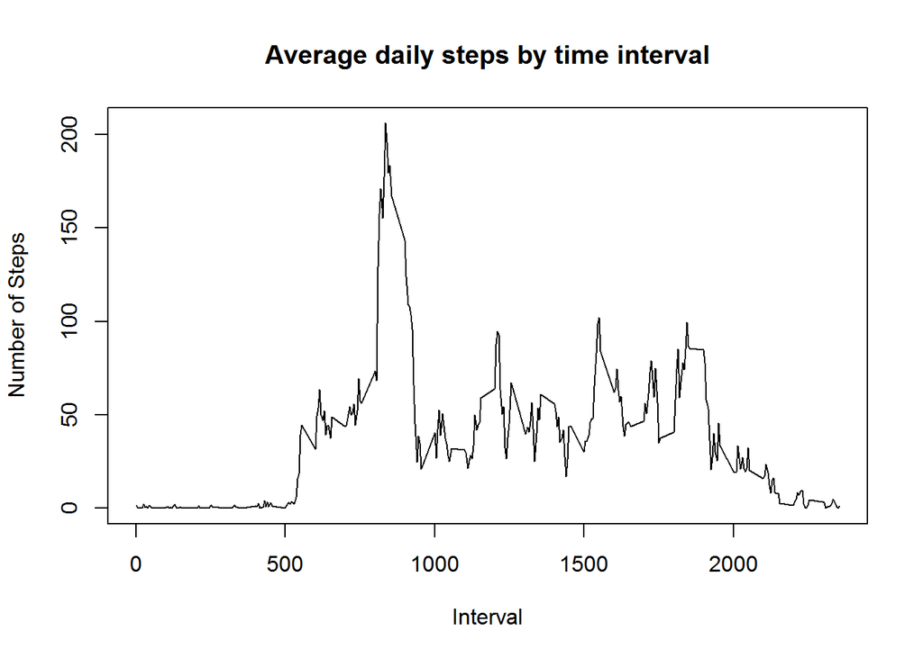

```r
steps_interval <- aggregate(steps ~ interval, data, mean)

plot(steps_interval$interval, steps_interval$steps, type="l", xlab="Interval", ylab="Number of Steps",
     main = "Average daily steps by time interval")
```

```r
max_interval <- steps_interval[which.max(steps_interval$steps),1]
```

## Impute missing values and compare the results from imputed to non imputed data

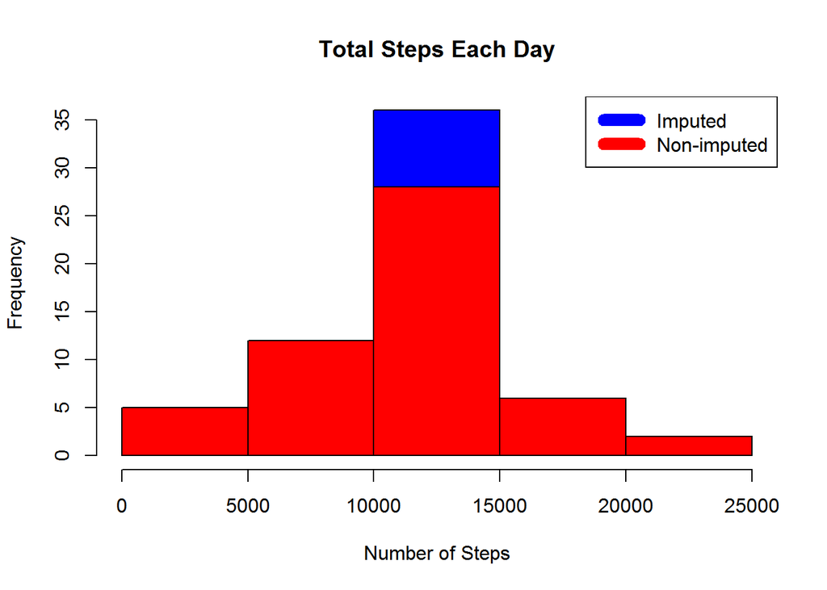

```r
incomplete <- sum(!complete.cases(data))
imputed_data <- transform(data, steps = ifelse(is.na(data$steps), steps_interval$steps[match(data$interval, steps_interval$interval)], data$steps))

steps_by_day_i <- aggregate(steps ~ date, imputed_data, sum)
hist(steps_by_day_i$steps, main = paste("Total Steps Each Day"), col="blue", xlab="Number of Steps")

#Create Histogram to show difference.
hist(steps_by_day$steps, main = paste("Total Daily Steps"), col="red", xlab="Number of Steps", add=T)
legend("topright", c("Imputed", "Non-imputed"), col=c("blue", "red"), lwd=10)
```

Calculate new mean and median for the imputed data.

```r
rmean.i <- mean(steps_by_day_i$steps)
rmedian.i <- median(steps_by_day_i$steps)
```

Calculate difference between imputed and non imputed data

```r
mean_diff <- rmean.i - rmean
med_diff <- rmedian.i - rmedian
```

Calculate the total difference

```r
total_diff <- sum(steps_by_day_i$steps) - sum(steps_by_day$steps)
```

## Are there any differences between weekday and weekend step counts?

Step volumes during weekdays vs. weekend days were analysed to observe any differences.

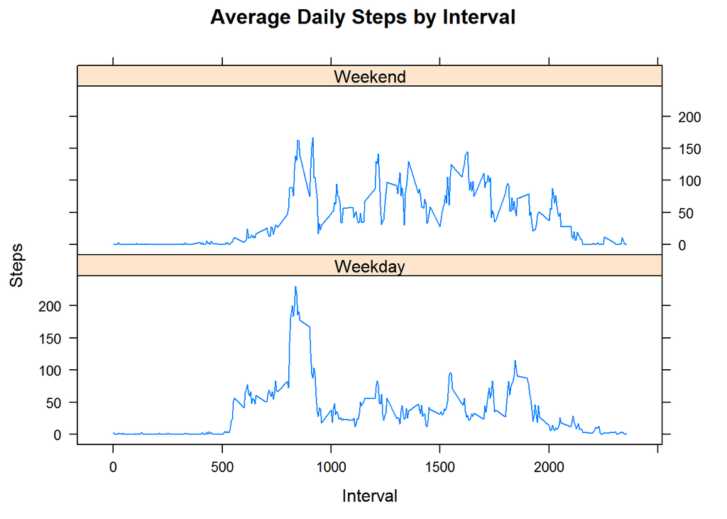

```r
weekdays <- c("Monday", "Tuesday", "Wednesday", "Thursday",
              "Friday")
imputed_data$wkday = as.factor(ifelse(is.element(weekdays(as.Date(imputed_data$date)),weekdays), "Weekday", "Weekend"))

steps_by_interval_i <- aggregate(steps ~ interval + wkday, imputed_data, mean)

library(lattice)

xyplot(steps_by_interval_i$steps ~ steps_by_interval_i$interval|steps_by_interval_i$wkday, main="Average Daily Steps by Interval",xlab="Interval", ylab="Steps",layout=c(1,2), type="l")
```